# Lydia_ModelFinal

## 2.

Now we proceed to check our residuals vs fitted model, QQ plot, etc.

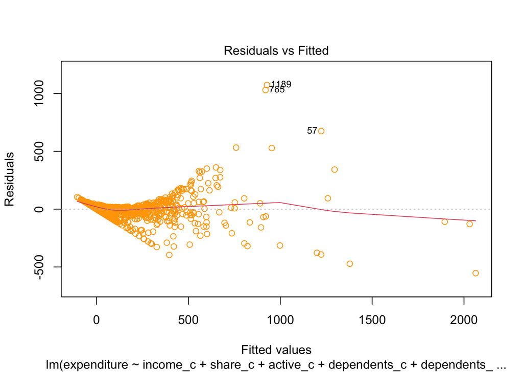

```r
  model_final <- model_no_quad

  plot(model_final, which = 1, col = "orange")
```

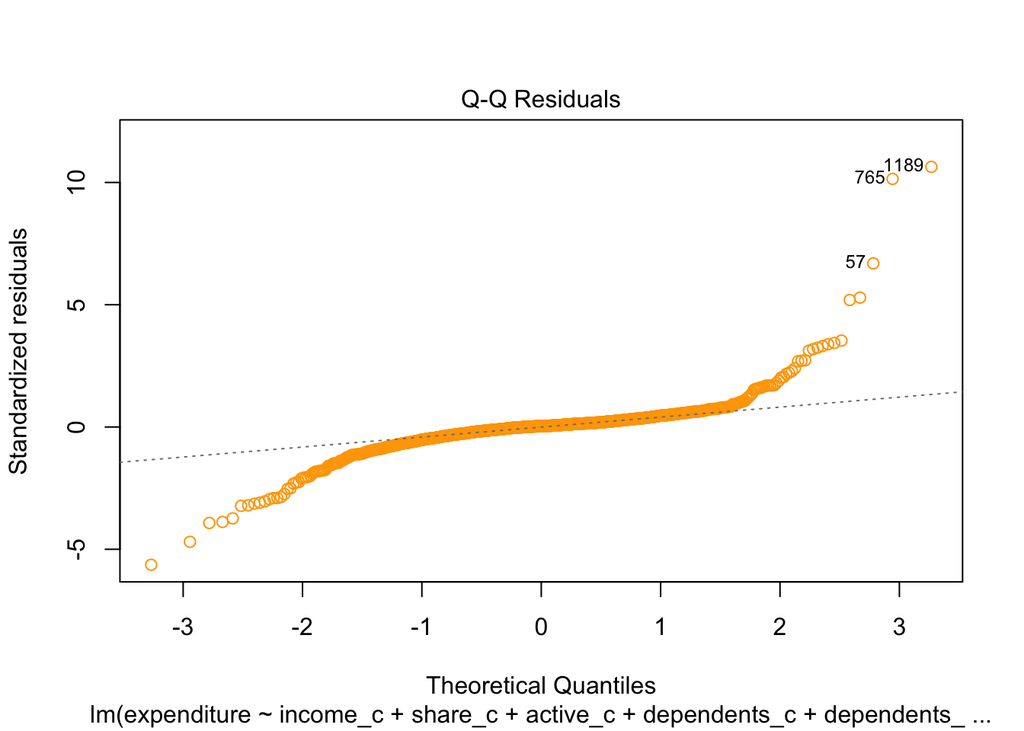

```r
  plot(model_final, which = 2, col = "orange")
```

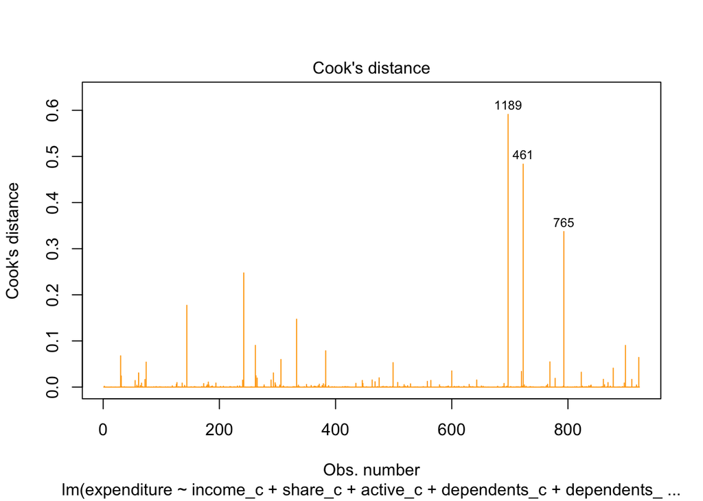

```r
# checking if outliers shuld be removed
  plot(model_final, which = 4, col = "orange")
```

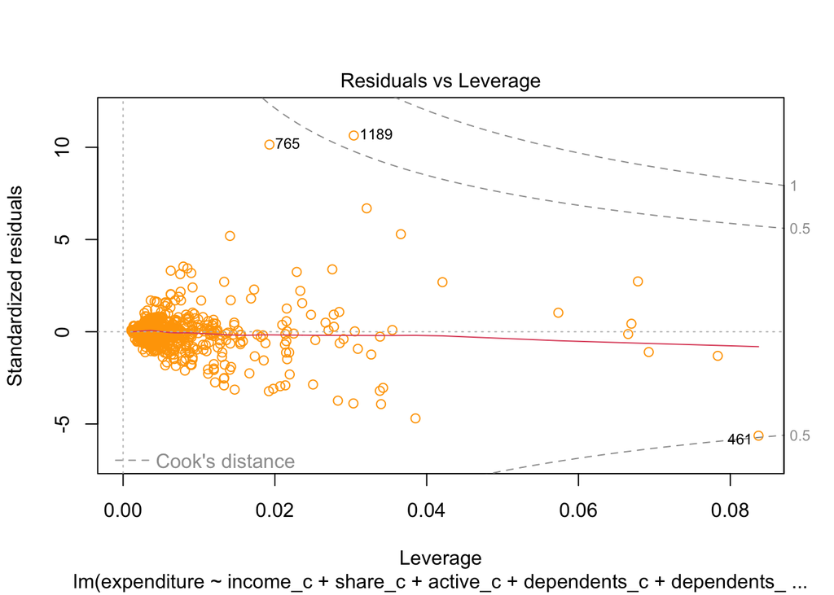

```r
  plot(model_final, which = 5, col = "orange")
```

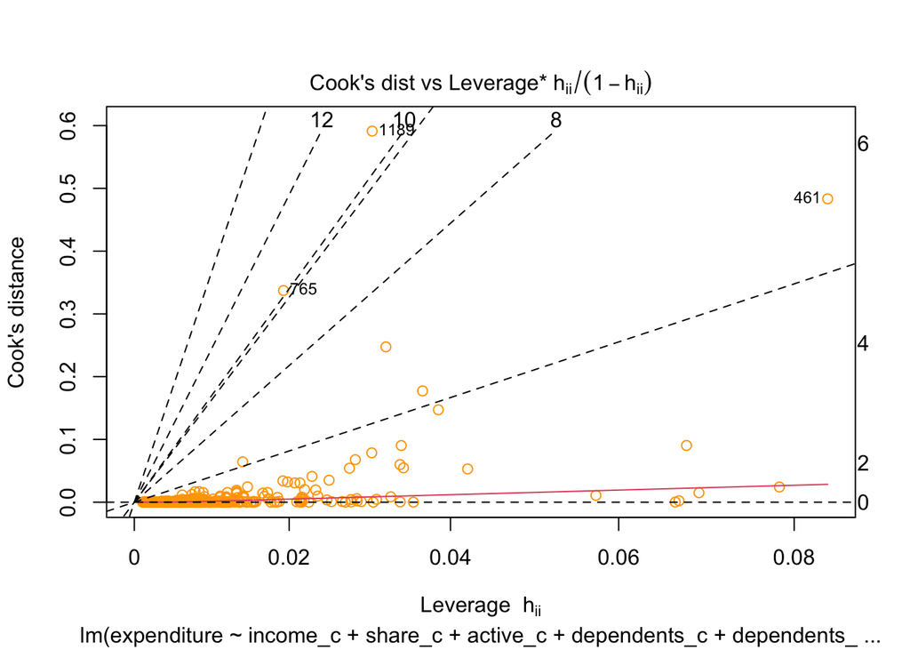

```r
  plot(model_final, which = 6, col = "orange")
```

Our residuals vs fitted and QQ residuals plots have stayed relatively the same compared to our simplified model, which is a positive note. However, looking at our Cook’s distance and Residuals vs Leverage plots, we can see that there are some points that may be described as highly influential. This should be looked into and removal of outliers should be considered.

```r
std_res <- rstandard(model_final)
outliers <- order(std_res, decreasing = TRUE)[1:3]
outliers
```

```
## [1] 697 793 242
```

```r
trainData_no_out <- trainData[-outliers, ]


# Refit the model
model_final_no_out <- lm(
  expenditure ~ income_c + share_c + active_c + dependents_c + dependents_c * active_c,
  data = trainData_no_out
)


summary(model_final_no_out)
```

```
##
## Call:
## lm(formula = expenditure ~ income_c + share_c + active_c + dependents_c +
##     dependents_c * active_c, data = trainData_no_out)
##
## Residuals:
##     Min      1Q  Median      3Q     Max
## -483.13  -27.53    0.54   25.21  569.92
##
## Coefficients:
##                        Estimate Std. Error t value Pr(>|t|)
## (Intercept)            178.8366     2.8531  62.682   <2e-16 ***
## income_c                43.9610     1.8341  23.969   <2e-16 ***
## share_c               2242.2583    30.2268  74.181   <2e-16 ***
## active_c                 1.1245     0.4636   2.426   0.0155 *
## dependents_c             2.5423     2.4185   1.051   0.2935
## active_c:dependents_c   -0.5871     0.4043  -1.452   0.1468
## ---
## Signif. codes:  0 '***' 0.001 '**' 0.01 '*' 0.05 '.' 0.1 ' ' 1
##
## Residual standard error: 86.19 on 914 degrees of freedom
## Multiple R-squared:  0.8672, Adjusted R-squared:  0.8664
## F-statistic:  1193 on 5 and 914 DF,  p-value: < 2.2e-16
```

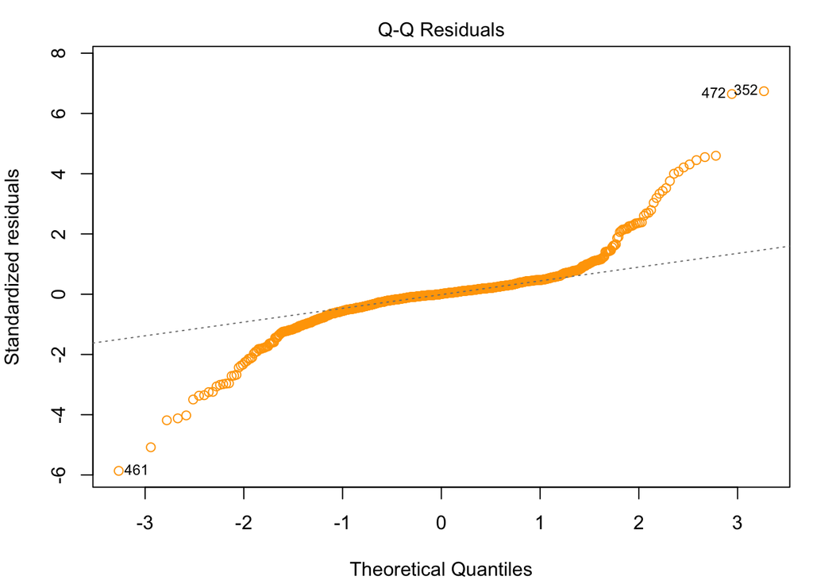

```r
# Residual vs fitted plot
par(mar = c(4,4,2,1))
plot(model_final_no_out, which = 2, col = "orange")
```

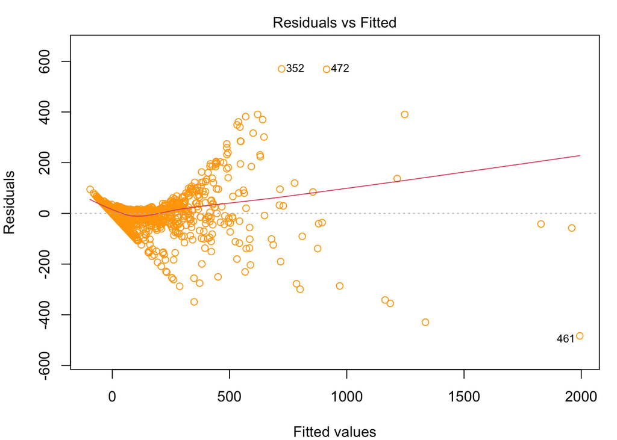

```r
plot(model_final_no_out, which = 1, col = "orange")
```

```r
  pred_out <- predict(model_final_no_out, newdata = trainData_no_out)
  rmse_out <- sqrt(mean((trainData_no_out$expenditure - pred_out)^2, na.rm = TRUE))
  rmse_out
```

```
## [1] 85.90584
```

Our RMSE and residuals have stayed relatively the same, but our adjusted R^2 has showed very minimal, almost insignificant improvement.

## 3.

```r
pred_test <- predict(model_final_no_out, newdata = testData)
RMSE <- sqrt(mean((testData$expenditure - pred_test)^2))
RMSE
```

```
## [1] 153.7357
```

```r
summary(model_final_no_out)$r.squared
```

```
## [1] 0.867151
```

## 4.